# eda_diamonds

```python
import pandas as pd

df = pd.read_csv('diamonds.csv')
df.head()
```

|  | Unnamed: 0 | carat | cut | color | clarity | depth | table | price | x | y | z |
| --- | --- | --- | --- | --- | --- | --- | --- | --- | --- | --- | --- |
| 0 | 1 | 0.23 | Ideal | E | SI2 | 61.5 | 55.0 | 326 | 3.95 | 3.98 | 2.43 |
| 1 | 2 | 0.21 | Premium | E | SI1 | 59.8 | 61.0 | 326 | 3.89 | 3.84 | 2.31 |
| 2 | 3 | 0.23 | Good | E | VS1 | 56.9 | 65.0 | 327 | 4.05 | 4.07 | 2.31 |
| 3 | 4 | 0.29 | Premium | I | VS2 | 62.4 | 58.0 | 334 | 4.20 | 4.23 | 2.63 |
| 4 | 5 | 0.31 | Good | J | SI2 | 63.3 | 58.0 | 335 | 4.34 | 4.35 | 2.75 |

Dataset values

```python
df.info()
```

```
<class 'pandas.core.frame.DataFrame'>
RangeIndex: 53940 entries, 0 to 53939
Data columns (total 11 columns):
 #   Column      Non-Null Count  Dtype
---  ------      --------------  -----
 0   Unnamed: 0  53940 non-null  int64
 1   carat       53940 non-null  float64
 2   cut         53940 non-null  object
 3   color       53940 non-null  object
 4   clarity     53940 non-null  object
 5   depth       53940 non-null  float64
 6   table       53940 non-null  float64
 7   price       53940 non-null  int64
 8   x           53940 non-null  float64
 9   y           53940 non-null  float64
 10  z           53940 non-null  float64
dtypes: float64(6), int64(2), object(3)
memory usage: 4.5+ MB
```

No null values, 6 float values, 2 int values and 3 object values

```python
df.describe()
```

|  | Unnamed: 0 | carat | depth | table | price | x | y | z |
| --- | --- | --- | --- | --- | --- | --- | --- | --- |
| count | 53940.000000 | 53940.000000 | 53940.000000 | 53940.000000 | 53940.000000 | 53940.000000 | 53940.000000 | 53940.000000 |
| mean | 26970.500000 | 0.797940 | 61.749405 | 57.457184 | 3932.799722 | 5.731157 | 5.734526 | 3.538734 |
| std | 15571.281097 | 0.474011 | 1.432621 | 2.234491 | 3989.439738 | 1.121761 | 1.142135 | 0.705699 |
| min | 1.000000 | 0.200000 | 43.000000 | 43.000000 | 326.000000 | 0.000000 | 0.000000 | 0.000000 |
| 25% | 13485.750000 | 0.400000 | 61.000000 | 56.000000 | 950.000000 | 4.710000 | 4.720000 | 2.910000 |
| 50% | 26970.500000 | 0.700000 | 61.800000 | 57.000000 | 2401.000000 | 5.700000 | 5.710000 | 3.530000 |
| 75% | 40455.250000 | 1.040000 | 62.500000 | 59.000000 | 5324.250000 | 6.540000 | 6.540000 | 4.040000 |
| max | 53940.000000 | 5.010000 | 79.000000 | 95.000000 | 18823.000000 | 10.740000 | 58.900000 | 31.800000 |

Description of numeric values

```python
df.isnull().sum()
```

```
Unnamed: 0    0
carat         0
cut           0
color         0
clarity       0
depth         0
table         0
price         0
x             0
y             0
z             0
dtype: int64
```

No null values

```python
print("Rows",df.shape[0]);
print("Columns",df.shape[1]);
print("Column names:", df.columns.tolist());
```

```
Rows 53940
Columns 11
Column names: ['Unnamed: 0', 'carat', 'cut', 'color', 'clarity', 'depth', 'table', 'price', 'x', 'y', 'z']
```

Number of rows and columns with names of the columns

```python
print("Cut\n",df['cut'].value_counts(),"\n");
print("Color\n",df['color'].value_counts(),"\n");
print("Clarity\n",df['clarity'].value_counts(),"\n");
```

```
Cut
 cut
Ideal        21551
Premium      13791
Very Good    12082
Good          4906
Fair          1610
Name: count, dtype: int64

Color
 color
G    11292
E     9797
F     9542
H     8304
D     6775
I     5422
J     2808
Name: count, dtype: int64

Clarity
 clarity
SI1     13065
VS2     12258
SI2      9194
VS1      8171
VVS2     5066
VVS1     3655
IF       1790
I1        741
Name: count, dtype: int64
```

Count of different diamonds based on types cut,color and clarity

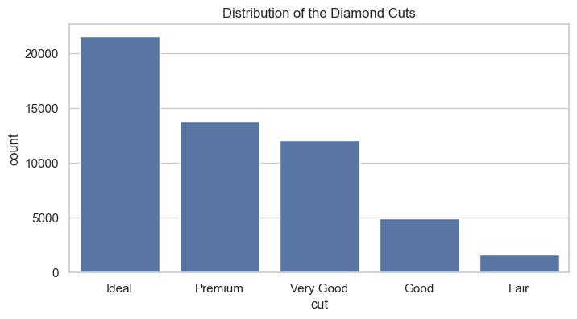

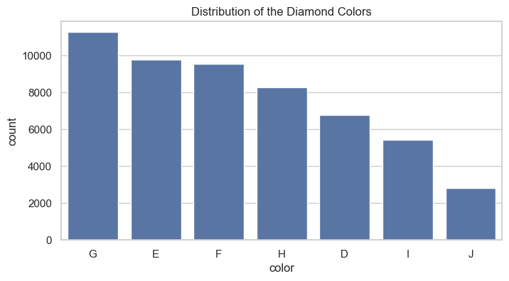

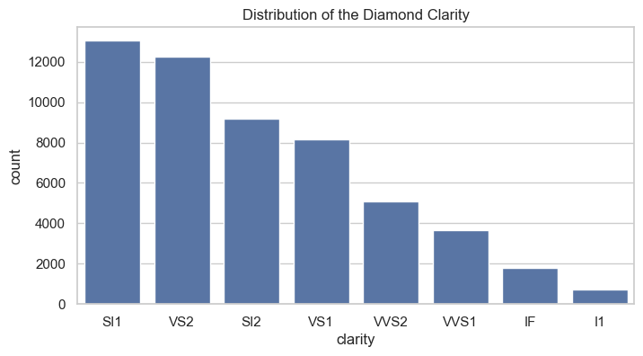

```python
import seaborn as sns
import matplotlib.pyplot as plt

sns.set(style="whitegrid");

plt.figure(figsize=(8,4));
sns.countplot(x='cut',data=df,order=df['cut'].value_counts().index);
plt.title("Distribution of the Diamond Cuts");
plt.show();

plt.figure(figsize=(8,4));
sns.countplot(x='color',data=df,order=df['color'].value_counts().index);
plt.title("Distribution of the Diamond Colors");
plt.show();

plt.figure(figsize=(8,4));
sns.countplot(x='clarity',data=df,order=df['clarity'].value_counts().index);
plt.title("Distribution of the Diamond Clarity");
plt.show();
```

- Ideal is the highest diamond cut by a margin
- G leads in color with E following
- SI1 has got the highest count in clarity of diamond with VS2 following close

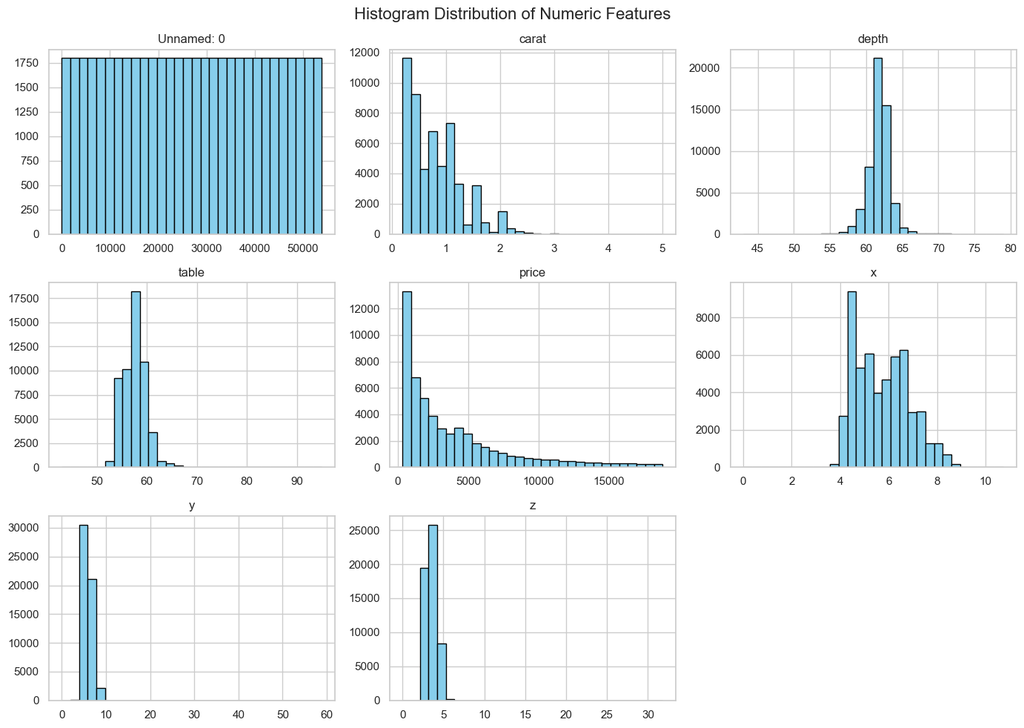

```python
df.hist(bins=30, figsize=(14, 10), color='skyblue', edgecolor='black')
plt.suptitle('Histogram Distribution of Numeric Features', fontsize=16)
plt.tight_layout()
plt.show()
```

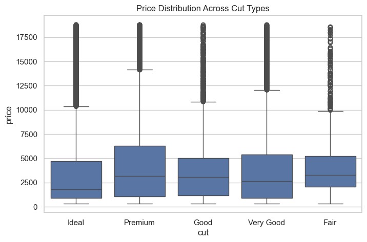

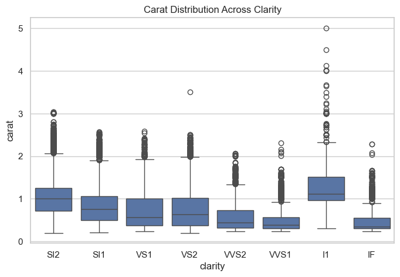

```python
plt.figure(figsize=(8, 5))
sns.boxplot(data=df, x='cut', y='price')
plt.title('Price Distribution Across Cut Types')
plt.show()

plt.figure(figsize=(8, 5))
sns.boxplot(data=df, x='clarity', y='carat')
plt.title('Carat Distribution Across Clarity')
plt.show()
```

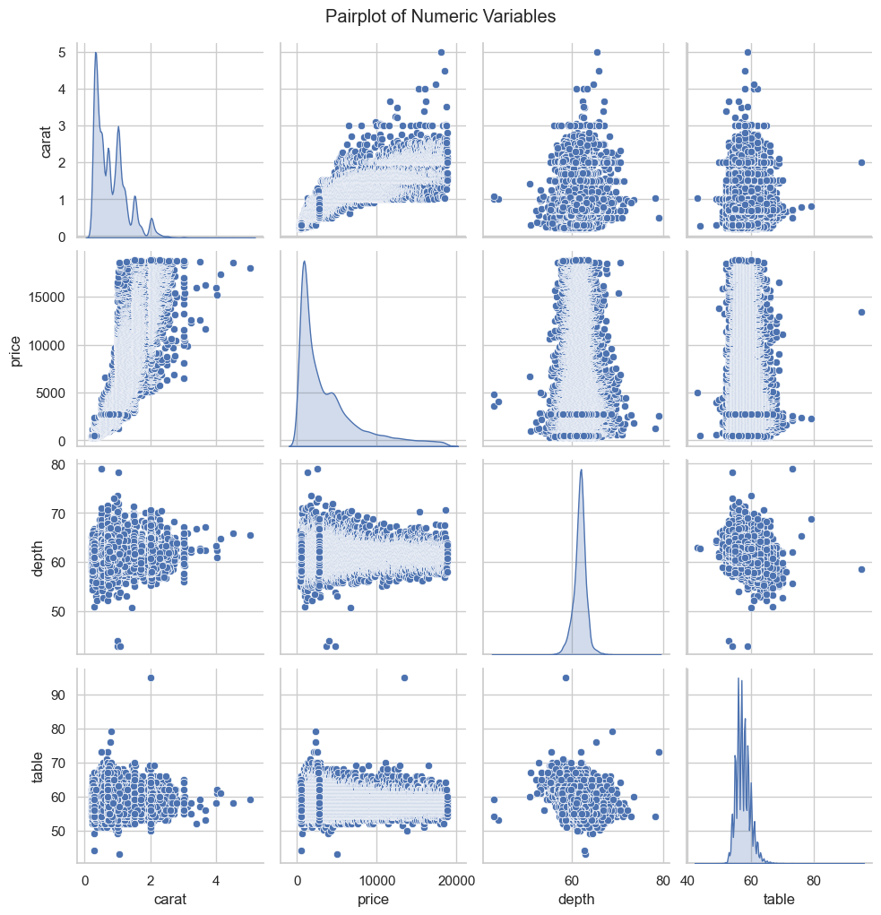

```python
# Pairplot for key features
sns.pairplot(df[['carat', 'price', 'depth', 'table']], diag_kind='kde')
plt.suptitle('Pairplot of Numeric Variables', y=1.02)
plt.show()
```

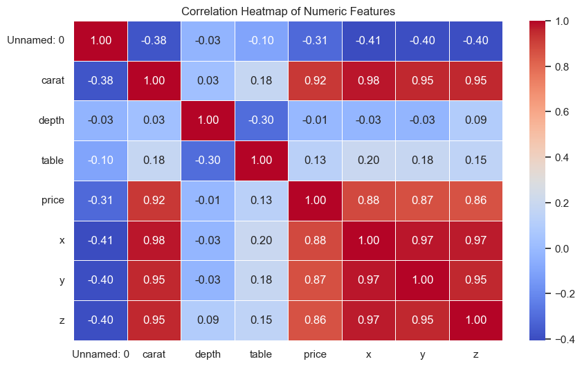

```python
corr_matrix = df.corr(numeric_only=True)

plt.figure(figsize=(10, 6))
sns.heatmap(corr_matrix, annot=True, fmt=".2f", cmap='coolwarm', linewidths=0.5)
plt.title('Correlation Heatmap of Numeric Features')
plt.show()
```

- Values +1 or -1 denotes strong relationship
- Thus can be inferred carat and price have strong coreation, so does carart and x,y,z
- Other factors like depth and table are weakly corealted with price as well as carat

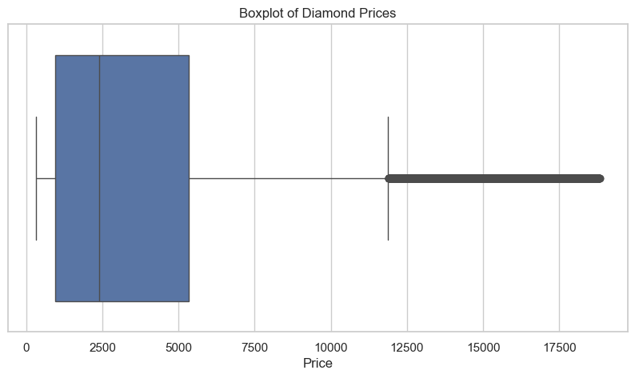

```python
plt.figure(figsize=(10, 5))
sns.boxplot(x=df['price'])
plt.title('Boxplot of Diamond Prices')
plt.xlabel('Price')
plt.show()
```

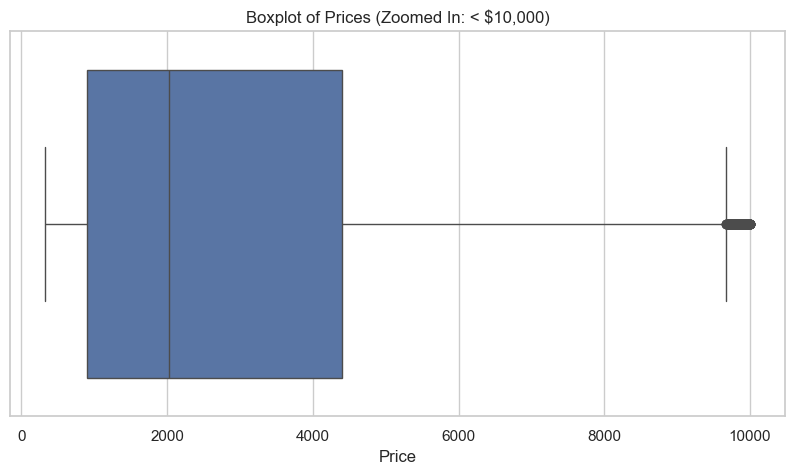

```python
plt.figure(figsize=(10, 5))
sns.boxplot(x=df[df['price'] < 10000]['price'])
plt.title('Boxplot of Prices (Zoomed In: < $10,000)')
plt.xlabel('Price')
plt.show()
```

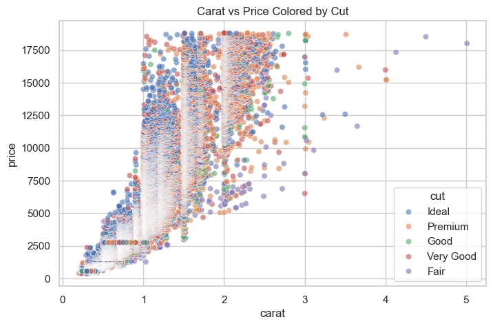

```python
plt.figure(figsize=(8, 5))
sns.scatterplot(data=df, x='carat', y='price', hue='cut', alpha=0.6)
plt.title('Carat vs Price Colored by Cut')
plt.show()
```

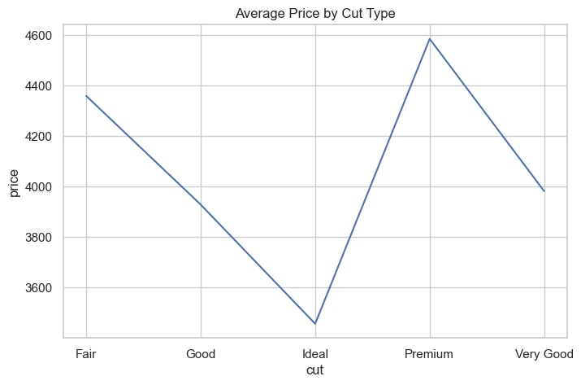

```python
plt.figure(figsize=(8, 5))
sns.lineplot(data=df.groupby('cut')['price'].mean().reset_index(), x='cut', y='price')
plt.title('Average Price by Cut Type')
plt.show()
```

- Box plot shows very high amounts of outliers
- But outliers tend to reduce when price comes below $10000
- Ideal Cut and Fair Cut seems to have the better pricing, with some fluctuations by the end
- Average price is increasing non linearly with reducing from fair to good to ideal and then going back up to premium to come back again at very good
- Ideal Cut seems to have the lowest price even with great quaity while Premium Cut has the highest price as expected

## **Final Data Summary**

The exploratory data analysis on diamond dataset revealed the following:

- **Carat** is the price maker of the diamonds
- *Cut*,*Color* and *calrity* plays it's role but not as much as carat
- Outliers does exist especially when price goes into premium ranges (above $10k)
- Ideal cut are the most commom type of diamond given the better price at a great quality thus showing great market preference
- For further quality analysis dataplots (x,y,z) can be validated